# CCE_Final

Ryan Peckner

8/11/2021

We will be using the provided base model as our point of departure. Let’s load the economy component from the model and calculate per capita consumption growth.

```r
options(digits=15)

library(readxl)
library(dplyr)
base_model = read_xlsx("Final Exam Base Model File.xlsx",
                       skip=87,n_max=8,col_names = FALSE)
```

```
## * `` -> ...1
## * `` -> ...2
## * `` -> ...3
## * `` -> ...4
## * `` -> ...5
## * ...
```

```r
base_model_data = type.convert(as.matrix(base_model[,-1]),as.is = FALSE)
base_model_data = t(base_model_data)
colnames(base_model_data) = make.names(base_model$...1)
base_model = as.data.frame(base_model_data)
base_model$Year = seq(2010,2300)
base_model = base_model %>% relocate(Year)
base_model$per.capita.consumption.growth = numeric(nrow(base_model))

for (i in 2:nrow(base_model)) {
  base_model$per.capita.consumption.growth[i] =
    (base_model$Per.capita.consumption...thousand.[i] - base_model$Per.capita.consumption...thousand.[i-1])/base_model$Per.capita.consumption...thousand.[i-1]
}

print(head(base_model))
```

```
##      Year Capital...trill. Gross.Output...trill. Output.per.capita...thous.cap.
## ...2 2010 139.650000000000      58.9749360570920               8.54709218218725
## ...3 2011 138.634574919570      60.2364111634207               8.61926293752712
## ...4 2012 137.996456252167      61.5240921108469               8.69366283557989
## ...5 2013 137.703586222350      62.8382802305781               8.77032303461227
## ...6 2014 137.727175473326      64.1792679037610               8.84927547479098
## ...7 2015 138.041374158191      65.5473358848244               8.93055261318389
##      Investment...trill. Net.Output...trill. Population..million.
## ...2    12.9495749195697    58.8617041798624     6900.00000000000
## ...3    13.2253388245543    60.1151764752467     6988.58029973299
## ...4    13.5067755953994    61.3944345245426     7076.88960043998
## ...5    13.7939478732110    62.6997630600499     7164.87636573766
## ...6    14.0869162321974    64.0314374190792     7252.48841971178
## ...7    14.3857385939362    65.3897208815281     7339.67299941316
##           Consumption Per.capita.consumption...thousand.
## ...2 45.9121292602927                   6.65393177685401
## ...3 46.8898376506924                   6.70949400874508
## ...4 47.8876589291432                   6.76676642322723
## ...5 48.9058151868389                   6.82577237769319
## ...6 49.9445211868818                   6.88653580626698
## ...7 51.0039822875919                   6.94908101378221
##      per.capita.consumption.growth
## ...2           0.00000000000000000
## ...3           0.00835028577905557
## ...4           0.00853602587728701
## ...5           0.00871996324025902
## ...6           0.00890205902153520
## ...7           0.00908224530805630
```

Now let’s compute the Ramsey discount factor for each year with the 1% pure rate of time preference.

```r
base_model$ramsey.discount.rate_0.01prtp = 0.01 + base_model$per.capita.consumption.growth
base_model$ramsey.discount.factor_0.01prtp = numeric(nrow(base_model))
base_model$ramsey.discount.factor_0.01prtp[1] = 1

for (i in 2:nrow(base_model)) {
  base_model$ramsey.discount.factor_0.01prtp[i] =
    prod(1/(1+base_model$ramsey.discount.rate_0.01prtp[2:i]))
}
```

**Question 1** *How does the Social Cost of Carbon change for different pure rate of time preference rates?*

We can now use the Ramsey discount factors to compute the SCC given the 1% prtp. First we need to add the marginal damages from an additional ton of carbon dioxide emissions to our model. As the numbers in the given model are calculated for an addition ton of carbon, we need to convert them to marginal damages per addition ton of CO2:

```r
marginal_damages = read_xlsx("Final Exam Base Model File.xlsx",
                             sheet=3,skip=6,n_max=1,col_names = FALSE)
```

```
## * `` -> ...1
## * `` -> ...2
## * `` -> ...3
## * `` -> ...4
## * `` -> ...5
## * ...
```

```r
base_model$marginal_damages = (12/44)*as.numeric(marginal_damages[,-1])
base_model$net.present.value_marginal.damages_0.01prtp =
  base_model$ramsey.discount.factor_0.01prtp*base_model$marginal_damages

scc_0.01prtp = sum(base_model$net.present.value_marginal.damages_0.01prtp)
print(scc_0.01prtp)
```

```
## [1] 48.1495476334819
```

Now we will repeat the above calculations for prtp values of 0% and 3%.

```r
base_model$ramsey.discount.rate_0prtp = 0 + base_model$per.capita.consumption.growth
base_model$ramsey.discount.factor_0prtp = numeric(nrow(base_model))
base_model$ramsey.discount.factor_0prtp[1] = 1

for (i in 2:nrow(base_model)) {
  base_model$ramsey.discount.factor_0prtp[i] =
    prod(1/(1+base_model$ramsey.discount.rate_0prtp[2:i]))
}
base_model$net.present.value_marginal.damages_0prtp =
  base_model$ramsey.discount.factor_0prtp*base_model$marginal_damages

scc_0prtp = sum(base_model$net.present.value_marginal.damages_0prtp)

base_model$ramsey.discount.rate_0.03prtp = 0.03 + base_model$per.capita.consumption.growth
base_model$ramsey.discount.factor_0.03prtp = numeric(nrow(base_model))
base_model$ramsey.discount.factor_0.03prtp[1] = 1

for (i in 2:nrow(base_model)) {
  base_model$ramsey.discount.factor_0.03prtp[i] =
    prod(1/(1+base_model$ramsey.discount.rate_0.03prtp[2:i]))
}
base_model$net.present.value_marginal.damages_0.03prtp =
  base_model$ramsey.discount.factor_0.03prtp*base_model$marginal_damages

scc_0.03prtp = sum(base_model$net.present.value_marginal.damages_0.03prtp)

scc = data.frame(prtp=c(0,0.01,0.03),
                 scc=c(scc_0prtp,scc_0.01prtp,scc_0.03prtp))
print(scc)
```

```
##   prtp                scc
## 1 0.00 194.74680224161855
## 2 0.01  48.14954763348190
## 3 0.03   8.81814145279981
```

**Question 2** *How do non-discounted marginal damage estimates over time compare to discounted marginal damage estimates?*

Let’s add the discounted marginal damages from assignment 6 to our model.

```r
npv_marginal.damages_0.03constant.discount.rate =
  read_xlsx("Final Exam Base Model File.xlsx",
                             sheet=3,skip=11,n_max=1,col_names = FALSE)
```

```
## * `` -> ...1
## * `` -> ...2
## * `` -> ...3
## * `` -> ...4
## * `` -> ...5
## * ...
```

```r
base_model$npv_marginal.damages_0.03constant.discount.rate = (12/44)*as.numeric(npv_marginal.damages_0.03constant.discount.rate[,-1])

npv_marginal.damages_0.025constant.discount.rate =
  read_xlsx("Final Exam Base Model File.xlsx",
                             sheet=3,skip=18,n_max=1,col_names = FALSE)
```

```
## * `` -> ...1
## * `` -> ...2
## * `` -> ...3
## * `` -> ...4
## * `` -> ...5
## * ...
```

```r
base_model$npv_marginal.damages_0.025constant.discount.rate = (12/44)*as.numeric(npv_marginal.damages_0.025constant.discount.rate[,-1])

npv_marginal.damages_0.05constant.discount.rate =
  read_xlsx("Final Exam Base Model File.xlsx",
                             sheet=3,skip=25,n_max=1,col_names = FALSE)
```

```
## * `` -> ...1
## * `` -> ...2
## * `` -> ...3
## * `` -> ...4
## * `` -> ...5
## * ...
```

```r
base_model$npv_marginal.damages_0.05constant.discount.rate = (12/44)*as.numeric(npv_marginal.damages_0.05constant.discount.rate[,-1])
```

Now we will plot the various calculated discounted and undiscounted marginal damages for comparison.

```r
library(reshape2)
library(ggplot2,quietly = T)
hrbrthemes::import_roboto_condensed()
```

```
## You will likely need to install these fonts on your system as well.
##
## You can find them in [/Library/Frameworks/R.framework/Versions/4.1/Resources/library/hrbrthemes/fonts/roboto-condensed]
```

```r
library(hrbrthemes, quietly = T)
d <- read.csv(extrafont:::fonttable_file(), stringsAsFactors = FALSE)
d[grepl("Light", d$FontName),]$FamilyName <- font_rc_light
write.csv(d,extrafont:::fonttable_file(), row.names = FALSE)
extrafont::loadfonts()
```

```
## Registering font with R using pdfFonts(): Roboto Condensed
```

```
## Registering font with R using pdfFonts(): Roboto Condensed Light
```

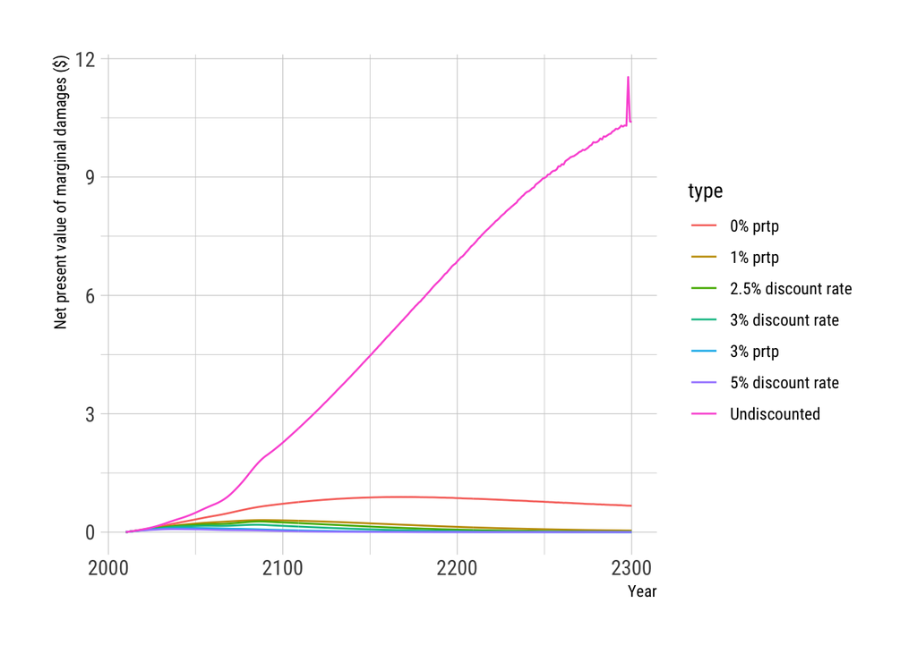

```r
library(gcookbook,quietly = T)

df = melt(base_model[c("Year",
                       grep("marginal.damages",names(base_model),value=TRUE))],
          id.vars = "Year")

df$type="Undiscounted"
df$type[grep("0prtp",df$variable)] = "0% prtp"
df$type[grep("0.01prtp",df$variable)] = "1% prtp"
df$type[grep("0.03prtp",df$variable)] = "3% prtp"
df$type[grep("0.025constant.discount.rate",df$variable)] = "2.5% discount rate"
df$type[grep("0.03constant.discount.rate",df$variable)] = "3% discount rate"
df$type[grep("0.05constant.discount.rate",df$variable)] = "5% discount rate"

ggplot(df,aes(x=Year,y=value)) + geom_line(aes(color=type)) +
        theme_ipsum_rc() + ylab("Net present value of marginal damages ($)")
```

Next, we produce the same plot without the undiscounted marginal damages:

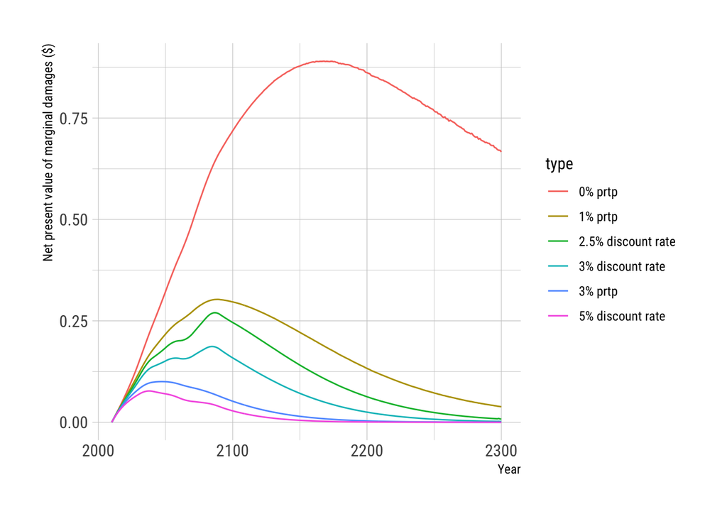

```r
ggplot(subset(df, type != "Undiscounted"),aes(x=Year,y=value)) + geom_line(aes(color=type)) +
        theme_ipsum_rc() + ylab("Net present value of marginal damages ($)")
```

**Question 3**: *How does the SCC change for different values of the climate sensitivity?*

The two new values of climate sensitive we will consider are
$$\lambda_{2} = \frac{2}{5.35 \ln2} \approx 0.5$$
and
$$\lambda_{4.5} = \frac{4.5}{5.35 \ln2} \approx 1.2.$$
We will create new versions of the model for each of these parameters and run them separately.

```r
Psi = 0.003
Damage = function(temperature) {
  return(Psi*(temperature^2))
}
source("CCE_Lab1_MainFunctions_0.5lambda.R")

base_emissions = read_xlsx("Final Exam Base Model File.xlsx",
                             sheet=1,skip=70,n_max=1,col_names = FALSE)
```

```
## * `` -> ...1
## * `` -> ...2
## * `` -> ...3
## * `` -> ...4
## * `` -> ...5
## * ...
```

```r
base_model$base.emissions =
  as.numeric(base_emissions[,-1])
base_model$emissions_additional.ton.carbon = base_model$base.emissions
base_model$emissions_additional.ton.carbon[2] =
  base_model$emissions_additional.ton.carbon[2] + 1e-6
base_model$temp.increase_0.5climate.sensitivity=
   sapply(1:nrow(base_model),
          GlobalAvgTempIncrease_FromEmissions,
          emissions=base_model$base.emissions)
base_model$damages_0.5climate.sensitivity=
  sapply(base_model$temp.increase_0.5climate.sensitivity,Damage)
base_model$damages_0.5climate.sensitivity_dollars=
  1e12*base_model$damages_0.5climate.sensitivity*base_model$Gross.Output...trill.

base_model$temp.increase_additional.ton.carbon_0.5climate.sensitivity =
  sapply(1:nrow(base_model),
          GlobalAvgTempIncrease_FromEmissions,
          emissions=base_model$emissions_additional.ton.carbon)
base_model$damages_additional.ton.carbon_0.5climate.sensitivity=
  sapply(base_model$temp.increase_additional.ton.carbon_0.5climate.sensitivity,Damage)
base_model$damages_additional.ton.carbon_0.5climate.sensitivity_dollars=
  1e12*base_model$damages_additional.ton.carbon_0.5climate.sensitivity*base_model$Gross.Output...trill.

base_model$marginal.damages_additional.ton.carbon_0.5climate.sensitivity_dollars=
  base_model$damages_additional.ton.carbon_0.5climate.sensitivity_dollars -
  base_model$damages_0.5climate.sensitivity_dollars
```

Now let’s compute the net present value of marginal damages and social cost of carbon for the 0.5 sensitivity parameter under constant discount schemes.

```r
ConstantDiscountFactor = function(t,discount_rate) {
  return(1/((1+discount_rate)^t))
}

base_model$discount.factor_0.03discount.rate =
  sapply(seq(0,nrow(base_model)-1),ConstantDiscountFactor,discount_rate = 0.03)
base_model$discount.factor_0.025discount.rate =
  sapply(seq(0,nrow(base_model)-1),ConstantDiscountFactor,discount_rate = 0.025)
base_model$discount.factor_0.05discount.rate =
  sapply(seq(0,nrow(base_model)-1),ConstantDiscountFactor,discount_rate = 0.05)


base_model$net.present.value_marginal.damages_additional.ton.carbon_0.5climate.sensitivity_0.03discount.rate_dollars =
     base_model$marginal.damages_additional.ton.carbon_0.5climate.sensitivity_dollars*base_model$discount.factor_0.03discount.rate
base_model$net.present.value_marginal.damages_additional.ton.CO2_0.5climate.sensitivity_0.03discount.rate_dollars = (12/44)*base_model$net.present.value_marginal.damages_additional.ton.carbon_0.5climate.sensitivity_0.03discount.rate

base_model$net.present.value_marginal.damages_additional.ton.carbon_0.5climate.sensitivity_0.025discount.rate_dollars =
     base_model$marginal.damages_additional.ton.carbon_0.5climate.sensitivity_dollars*base_model$discount.factor_0.025discount.rate
base_model$net.present.value_marginal.damages_additional.ton.CO2_0.5climate.sensitivity_0.025discount.rate_dollars = (12/44)*base_model$net.present.value_marginal.damages_additional.ton.carbon_0.5climate.sensitivity_0.025discount.rate

base_model$net.present.value_marginal.damages_additional.ton.carbon_0.5climate.sensitivity_0.05discount.rate_dollars =
     base_model$marginal.damages_additional.ton.carbon_0.5climate.sensitivity_dollars*base_model$discount.factor_0.05discount.rate
base_model$net.present.value_marginal.damages_additional.ton.CO2_0.5climate.sensitivity_0.05discount.rate_dollars = (12/44)*base_model$net.present.value_marginal.damages_additional.ton.carbon_0.5climate.sensitivity_0.05discount.rate


scc_0.5climate.sensitivity_0.03discount.rate =
  sum(base_model$net.present.value_marginal.damages_additional.ton.CO2_0.5climate.sensitivity_0.03discount.rate_dollars)
scc_0.5climate.sensitivity_0.025discount.rate =
  sum(base_model$net.present.value_marginal.damages_additional.ton.CO2_0.5climate.sensitivity_0.025discount.rate_dollars)
scc_0.5climate.sensitivity_0.05discount.rate =
  sum(base_model$net.present.value_marginal.damages_additional.ton.CO2_0.5climate.sensitivity_0.05discount.rate_dollars)
```

Finally, we compute the net present value of marginal damages and social cost of carbon for the 0.5 sensitivity parameter under the Ramsey discount schemes.

```r
base_model$net.present.value_marginal.damages_additional.ton.carbon_0.5climate.sensitivity_0.01prtp_dollars =
  base_model$ramsey.discount.factor_0.01prtp*base_model$marginal.damages_additional.ton.carbon_0.5climate.sensitivity_dollars
base_model$net.present.value_marginal.damages_additional.ton.CO2_0.5climate.sensitivity_0.01prtp_dollars =
  (12/44)*base_model$net.present.value_marginal.damages_additional.ton.carbon_0.5climate.sensitivity_0.01prtp_dollars

base_model$net.present.value_marginal.damages_additional.ton.carbon_0.5climate.sensitivity_0prtp_dollars =
  base_model$ramsey.discount.factor_0prtp*base_model$marginal.damages_additional.ton.carbon_0.5climate.sensitivity_dollars
base_model$net.present.value_marginal.damages_additional.ton.CO2_0.5climate.sensitivity_0prtp_dollars =
  (12/44)*base_model$net.present.value_marginal.damages_additional.ton.carbon_0.5climate.sensitivity_0prtp_dollars

base_model$net.present.value_marginal.damages_additional.ton.carbon_0.5climate.sensitivity_0.03prtp_dollars =
  base_model$ramsey.discount.factor_0.03prtp*base_model$marginal.damages_additional.ton.carbon_0.5climate.sensitivity_dollars
base_model$net.present.value_marginal.damages_additional.ton.CO2_0.5climate.sensitivity_0.03prtp_dollars =
  (12/44)*base_model$net.present.value_marginal.damages_additional.ton.carbon_0.5climate.sensitivity_0.03prtp_dollars

scc_0.5climate.sensitivity_0.01prtp =
  sum(base_model$net.present.value_marginal.damages_additional.ton.CO2_0.5climate.sensitivity_0.01prtp_dollars)
scc_0.5climate.sensitivity_0prtp =
  sum(base_model$net.present.value_marginal.damages_additional.ton.CO2_0.5climate.sensitivity_0prtp_dollars)
scc_0.5climate.sensitivity_0.03prtp =
  sum(base_model$net.present.value_marginal.damages_additional.ton.CO2_0.5climate.sensitivity_0.03prtp_dollars)
```

Now we will repeat all of the above calculations for a climate sensitivity of 1.2, which corresponds to 4.5 degrees of warming.

```r
Psi = 0.003
Damage = function(temperature) {
  return(Psi*(temperature^2))
}
source("CCE_Lab1_MainFunctions_1.2lambda.R")

base_emissions = read_xlsx("Final Exam Base Model File.xlsx",
                             sheet=1,skip=70,n_max=1,col_names = FALSE)
```

```
## * `` -> ...1
## * `` -> ...2
## * `` -> ...3
## * `` -> ...4
## * `` -> ...5
## * ...
```

```r
base_model$base.emissions =
  as.numeric(base_emissions[,-1])
base_model$emissions_additional.ton.carbon = base_model$base.emissions
base_model$emissions_additional.ton.carbon[2] =
  base_model$emissions_additional.ton.carbon[2] + 1e-6
base_model$temp.increase_1.2climate.sensitivity=
   sapply(1:nrow(base_model),
          GlobalAvgTempIncrease_FromEmissions,
          emissions=base_model$base.emissions)
base_model$damages_1.2climate.sensitivity=
  sapply(base_model$temp.increase_1.2climate.sensitivity,Damage)
base_model$damages_1.2climate.sensitivity_dollars=
  1e12*base_model$damages_1.2climate.sensitivity*base_model$Gross.Output...trill.

base_model$temp.increase_additional.ton.carbon_1.2climate.sensitivity =
  sapply(1:nrow(base_model),
          GlobalAvgTempIncrease_FromEmissions,
          emissions=base_model$emissions_additional.ton.carbon)
base_model$damages_additional.ton.carbon_1.2climate.sensitivity=
  sapply(base_model$temp.increase_additional.ton.carbon_1.2climate.sensitivity,Damage)
base_model$damages_additional.ton.carbon_1.2climate.sensitivity_dollars=
  1e12*base_model$damages_additional.ton.carbon_1.2climate.sensitivity*base_model$Gross.Output...trill.

base_model$marginal.damages_additional.ton.carbon_1.2climate.sensitivity_dollars=
  base_model$damages_additional.ton.carbon_1.2climate.sensitivity_dollars -
  base_model$damages_1.2climate.sensitivity_dollars


ConstantDiscountFactor = function(t,discount_rate) {
  return(1/((1+discount_rate)^t))
}

base_model$discount.factor_0.03discount.rate =
  sapply(seq(0,nrow(base_model)-1),ConstantDiscountFactor,discount_rate = 0.03)
base_model$discount.factor_0.025discount.rate =
  sapply(seq(0,nrow(base_model)-1),ConstantDiscountFactor,discount_rate = 0.025)
base_model$discount.factor_0.05discount.rate =
  sapply(seq(0,nrow(base_model)-1),ConstantDiscountFactor,discount_rate = 0.05)


base_model$net.present.value_marginal.damages_additional.ton.carbon_1.2climate.sensitivity_0.03discount.rate_dollars =
     base_model$marginal.damages_additional.ton.carbon_1.2climate.sensitivity_dollars*base_model$discount.factor_0.03discount.rate
base_model$net.present.value_marginal.damages_additional.ton.CO2_1.2climate.sensitivity_0.03discount.rate_dollars = (12/44)*base_model$net.present.value_marginal.damages_additional.ton.carbon_1.2climate.sensitivity_0.03discount.rate

base_model$net.present.value_marginal.damages_additional.ton.carbon_1.2climate.sensitivity_0.025discount.rate_dollars =
     base_model$marginal.damages_additional.ton.carbon_1.2climate.sensitivity_dollars*base_model$discount.factor_0.025discount.rate
base_model$net.present.value_marginal.damages_additional.ton.CO2_1.2climate.sensitivity_0.025discount.rate_dollars = (12/44)*base_model$net.present.value_marginal.damages_additional.ton.carbon_1.2climate.sensitivity_0.025discount.rate

base_model$net.present.value_marginal.damages_additional.ton.carbon_1.2climate.sensitivity_0.05discount.rate_dollars =
     base_model$marginal.damages_additional.ton.carbon_1.2climate.sensitivity_dollars*base_model$discount.factor_0.05discount.rate
base_model$net.present.value_marginal.damages_additional.ton.CO2_1.2climate.sensitivity_0.05discount.rate_dollars = (12/44)*base_model$net.present.value_marginal.damages_additional.ton.carbon_1.2climate.sensitivity_0.05discount.rate


scc_1.2climate.sensitivity_0.03discount.rate =
  sum(base_model$net.present.value_marginal.damages_additional.ton.CO2_1.2climate.sensitivity_0.03discount.rate_dollars)
scc_1.2climate.sensitivity_0.025discount.rate =
  sum(base_model$net.present.value_marginal.damages_additional.ton.CO2_1.2climate.sensitivity_0.025discount.rate_dollars)
scc_1.2climate.sensitivity_0.05discount.rate =
  sum(base_model$net.present.value_marginal.damages_additional.ton.CO2_1.2climate.sensitivity_0.05discount.rate_dollars)


base_model$net.present.value_marginal.damages_additional.ton.carbon_1.2climate.sensitivity_0.01prtp_dollars =
  base_model$ramsey.discount.factor_0.01prtp*base_model$marginal.damages_additional.ton.carbon_1.2climate.sensitivity_dollars
base_model$net.present.value_marginal.damages_additional.ton.CO2_1.2climate.sensitivity_0.01prtp_dollars =
  (12/44)*base_model$net.present.value_marginal.damages_additional.ton.carbon_1.2climate.sensitivity_0.01prtp_dollars

base_model$net.present.value_marginal.damages_additional.ton.carbon_1.2climate.sensitivity_0prtp_dollars =
  base_model$ramsey.discount.factor_0prtp*base_model$marginal.damages_additional.ton.carbon_1.2climate.sensitivity_dollars
base_model$net.present.value_marginal.damages_additional.ton.CO2_1.2climate.sensitivity_0prtp_dollars =
  (12/44)*base_model$net.present.value_marginal.damages_additional.ton.carbon_1.2climate.sensitivity_0prtp_dollars

base_model$net.present.value_marginal.damages_additional.ton.carbon_1.2climate.sensitivity_0.03prtp_dollars =
  base_model$ramsey.discount.factor_0.03prtp*base_model$marginal.damages_additional.ton.carbon_1.2climate.sensitivity_dollars
base_model$net.present.value_marginal.damages_additional.ton.CO2_1.2climate.sensitivity_0.03prtp_dollars =
  (12/44)*base_model$net.present.value_marginal.damages_additional.ton.carbon_1.2climate.sensitivity_0.03prtp_dollars

scc_1.2climate.sensitivity_0.01prtp =
  sum(base_model$net.present.value_marginal.damages_additional.ton.CO2_1.2climate.sensitivity_0.01prtp_dollars)
scc_1.2climate.sensitivity_0prtp =
  sum(base_model$net.present.value_marginal.damages_additional.ton.CO2_1.2climate.sensitivity_0prtp_dollars)
scc_1.2climate.sensitivity_0.03prtp =
  sum(base_model$net.present.value_marginal.damages_additional.ton.CO2_1.2climate.sensitivity_0.03prtp_dollars)
```

We’re finally ready to show how the climate sensitivity parameters control the SCC for the six discounting schemes considered.

```r
scc_final = expand.grid(climate.sensitivity=c(0.5,1.2),
                       discounting.scheme=c("2.5% constant","3% constant","5% constant",
                                            "0% prtp","1% prtp","3% prtp"))
scc_final$scc_additional.ton.CO2 = numeric(nrow(scc_final))
scc_final$scc_additional.ton.CO2[1] = scc_0.5climate.sensitivity_0.025discount.rate
scc_final$scc_additional.ton.CO2[2] = scc_1.2climate.sensitivity_0.025discount.rate
scc_final$scc_additional.ton.CO2[3] = scc_0.5climate.sensitivity_0.03discount.rate
scc_final$scc_additional.ton.CO2[4] = scc_1.2climate.sensitivity_0.03discount.rate
scc_final$scc_additional.ton.CO2[5] = scc_0.5climate.sensitivity_0.05discount.rate
scc_final$scc_additional.ton.CO2[6] = scc_1.2climate.sensitivity_0.05discount.rate
scc_final$scc_additional.ton.CO2[7] = scc_0.5climate.sensitivity_0prtp
scc_final$scc_additional.ton.CO2[8] = scc_1.2climate.sensitivity_0prtp
scc_final$scc_additional.ton.CO2[9] = scc_0.5climate.sensitivity_0.01prtp
scc_final$scc_additional.ton.CO2[10] = scc_1.2climate.sensitivity_0.01prtp
scc_final$scc_additional.ton.CO2[11] = scc_0.5climate.sensitivity_0.03prtp
scc_final$scc_additional.ton.CO2[12] = scc_1.2climate.sensitivity_0.03prtp

print(scc_final)
```

```
##    climate.sensitivity discounting.scheme scc_additional.ton.CO2
## 1                  0.5      2.5% constant      14.19718145604360
## 2                  1.2      2.5% constant      72.84117042275120
## 3                  0.5        3% constant       9.06166193177327
## 4                  1.2        3% constant      45.22420522679728
## 5                  0.5        5% constant       2.55512986132552
## 6                  1.2        5% constant      11.45861078547080
## 7                  0.5            0% prtp      81.59096915066452
## 8                  1.2            0% prtp     448.51987348088340
## 9                  0.5            1% prtp      20.44763835331007
## 10                 1.2            1% prtp     107.08529846810248
## 11                 0.5            3% prtp       3.95776576347707
## 12                 1.2            3% prtp      18.44744182709805
```